# Preterit-Imperfect Appropriate Use Models 9-25-23

Sophia Minnillo

9/25/2023

This is a report of the models included in our paper

# COWS cross-sectional data

## 1: does accuracy of use differ between SPA 1 and all other course levels?

This is using the data from COWS: cross-sectional

```r
#just cows data can use
data_cows <- data %>%
  dplyr::filter(Subset == 'COWS_cross')
#view(data_cows)

#course levels
course_levelsb = c('SPA 1', 'SPA 2', 'SPA 3', 'SPA 21', 'SPA 22', 'SPA 23', 'SPA 24')

#for this RQ
data_rq1 <- data_cows %>%
  group_by(Corrected_num, Proficiency) %>%
  dplyr::summarize(`Mean Appropriateness` = mean(appropriateness))%>%
  dplyr::mutate(Proficiency = factor(Proficiency, levels = course_levelsb))
```

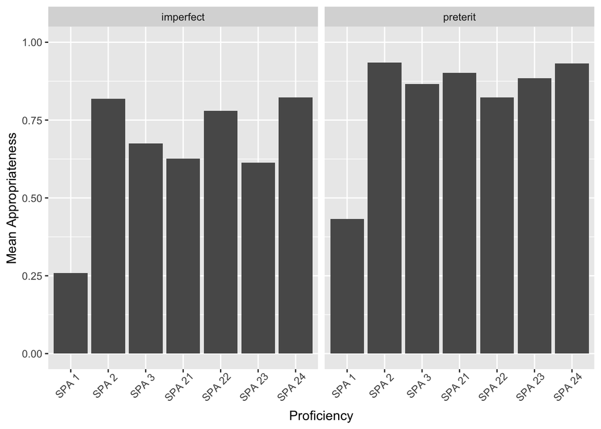

```r
#view(data_rq1)

#plot
ggplot(data_rq1,
       aes(x = Proficiency, y = `Mean Appropriateness`))+
  geom_col()+
  facet_wrap(~Corrected_num)+
  theme(axis.text.x = element_text(angle = 45, hjust = 0.75, vjust = 0.9))+
  ylim(0,1)
```

Separate into pre vs. post-instruction groups

```r
#separate into pre vs. post instruction
data_rq1_pre_instruction <- data_cows %>%
  filter(Proficiency == 'SPA 1')
#view(data_rq1_pre_instruction)

data_rq1_post_instruction <- data_cows %>%
  filter(Proficiency != 'SPA 1')
#view(data_rq1_post_instruction)

#only SPA 2
data_rq1_post_instruction_SPA2 <- data_cows %>%
  filter(Proficiency == 'SPA 2')
#view(data_rq1_post_instruction_SPA2)

#combine SPA 1 and 2 without stripping everything fro it
data_cows_SPA12 <- data_cows %>%
  dplyr::filter(Proficiency == 'SPA 1' | Proficiency == 'SPA 2')

#view(data_rq1_post_instruction_SPA2)
#filtering down data to just SPA 1 and 2
data_cows_SPA1and2 <- data_cows %>%
  dplyr::filter(Proficiency == 'SPA 1' | Proficiency == 'SPA 2')%>%
  dplyr::select(c(Proficiency, appropriateness))%>%
  mutate(appropriateness = as.character(appropriateness))
#view(data_cows_SPA1and2)
```

Let’s do the COWS course level 1 vs. 2 comparison through a mixed effects model instead of a Chi-Squared model.

### in paper

```r
#let's see if we can do this with a model instead
#clean up the dataset
data_cows_SPA12 <- data_cows_SPA12%>%
  mutate(
    infinitive = tolower(Infinitive_no_reflex))

#view(data_cows_SPA12)

modelrq3_1 <- glmer(appropriateness ~ Proficiency +
                      (1|Essay) + (1|infinitive), data_cows_SPA12,
                  family = 'binomial', control = glmerControl(optimizer="bobyqa", optCtrl=list(maxfun=50000)))

#appropriate (0=no, 1=yes) ~
#* Proficiency + random effect for essay and infinitive
summary(modelrq3_1)
```

```
## Generalized linear mixed model fit by maximum likelihood (Laplace
##   Approximation) [glmerMod]
##  Family: binomial  ( logit )
## Formula: appropriateness ~ Proficiency + (1 | Essay) + (1 | infinitive)
##    Data: data_cows_SPA12
## Control: glmerControl(optimizer = "bobyqa", optCtrl = list(maxfun = 50000))
##
##      AIC      BIC   logLik deviance df.resid
##    351.4    368.3   -171.7    343.4      500
##
## Scaled residuals:
##     Min      1Q  Median      3Q     Max
## -6.0986 -0.1900  0.1887  0.3203  3.2479
##
## Random effects:
##  Groups     Name        Variance Std.Dev.
##  infinitive (Intercept) 0.2003   0.4475
##  Essay      (Intercept) 3.8899   1.9723
## Number of obs: 504, groups:  infinitive, 116; Essay, 19
##
## Fixed effects:
##                  Estimate Std. Error z value Pr(>|z|)
## (Intercept)       -0.9194     0.7285  -1.262 0.206943
## ProficiencySPA 2   3.6535     0.9971   3.664 0.000248 ***
## ---
## Signif. codes:  0 '***' 0.001 '**' 0.01 '*' 0.05 '.' 0.1 ' ' 1
##
## Correlation of Fixed Effects:
##             (Intr)
## PrfcncySPA2 -0.729
```

```r
#get R^2 too
r.squaredGLMM(modelrq3_1)
```

```
##                   R2m       R2c
## theoretical 0.2755147 0.6770406
## delta       0.2551555 0.6270106
```

```r
#delta       0.2551555 0.6270106
```

#Cohen’s d

```r
#get cohen's d
#divide into groups by course
#calculate Cohen's d
cohen.d(data_rq1_post_instruction_SPA2$appropriateness, data_rq1_pre_instruction$appropriateness)
```

```
##
## Cohen's d
##
## d estimate: 1.420922 (large)
## 95 percent confidence interval:
##    lower    upper
## 1.210613 1.631231
```

```r
#d estimate: 1.420922 (large)
```

##### Effect Plot

```
## Confidence intervals for merMod models is an experimental feature. The
## intervals reflect only the variance of the fixed effects, not the random
## effects.
```

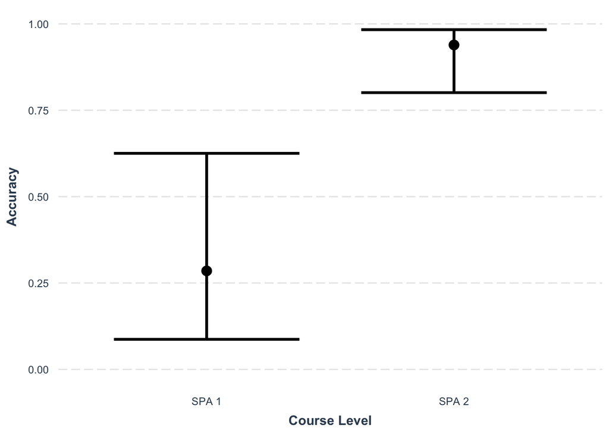

```r
#here, I'm trying to create effect plots for this first course level effect

#let's take a look at the dataset
#view(data_cows_SPA12)

#let's plot accuracy by course level
effect_plot(modelrq3_1, pred = Proficiency,
            x.label = 'Course Level',
            y.label = 'Accuracy'
            )+
  ylim(0, 1.0)
```

Cleaning data

## 2: Is course level a predictor of accuracy? No.

```r
#now just use SPA 2 on: data_rq1_post_instruction

#now, we'll be considering tense (binary), regularity (binary), and frequency (log-transformed continuous)
#tense and regularity will become +/- 0.5

#now let's center and scale the frequency data
center_scale <- function(x) {
    scale(x, scale = TRUE) #changed 9-28-22
  #scale = TRUE to center and scale
}
#this is from this blog https://www.gastonsanchez.com/visually-enforced/how-to/2014/01/15/Center-data-in-R/

#need to center the course levels
#SPA 2 = -2.5
#SPA 3 = -1.5
#SPA 21 = -.5
#SPA 22 = .5
#SPA 23 = 1.5
#SPA 24 = 2.5

#turn Proficiency levels into centered variable
data_rq1_post_instruction <- data_rq1_post_instruction %>%
  mutate(course_level = case_when(
    Proficiency == 'SPA 2' ~ 'level 2',
    Proficiency == 'SPA 3' ~ 'level 3',
    Proficiency == 'SPA 21' ~ 'level 4',
    Proficiency == 'SPA 22' ~ 'level 5',
    Proficiency == 'SPA 23' ~ 'level 6',
    Proficiency == 'SPA 24' ~ 'level 7'
  ))%>%
  mutate(course_level_cont = case_when(
    Proficiency == 'SPA 2' ~ -2.5,
    Proficiency == 'SPA 3' ~ -1.5,
    Proficiency == 'SPA 21' ~ -0.5,
    Proficiency == 'SPA 22' ~ 0.5,
    Proficiency == 'SPA 23' ~ 1.5,
    Proficiency == 'SPA 24' ~ 2.5
  ))%>%
  mutate(tense = case_when(
    Corrected_num == 'imperfect' ~ -0.5, #imperfect negative
    Corrected_num == 'preterit' ~ 0.5 #preterit positive
  ))%>%
  mutate(regularity = case_when(
    Regularity == 'I' ~ -0.5, #irregular is -0.5
    Regularity == 'R' ~ 0.5 #regular is 0.5 (positive)
  ))%>%
  mutate(
    #change 11-11-22: frequency as sum_log_frq
    frequency = center_scale(data_rq1_post_instruction$log_sum_frq)
    #frequency now ranges from approx. -2.7 to +1.53
  )%>%
  drop_na(regularity)%>% #getting rid of NAs, still 1801 observations
  mutate(
    infinitive = tolower(Infinitive_no_reflex)
  ) #change 9-28
#view(data_rq1_post_instruction)
```

## Preterit

```r
#just the preterit
data_rq1_post_instruction_pret <- data_rq1_post_instruction%>%
  filter(Corrected_num == 'preterit')
#view(data_rq1_post_instruction_pret)
```

## Imperfect

```r
#just the imperfect
data_rq1_post_instruction_imp <- data_rq1_post_instruction%>%
  filter(Corrected_num == 'imperfect')
#view(data_rq1_post_instruction_imp)
```

## Both

```r
#now let's model appropriateness without SPA 1
modelrq3_1 <- glmer(appropriateness ~ course_level +
                      (1|Essay) + (1|infinitive), data_rq1_post_instruction,
                  family = 'binomial', control = glmerControl(optimizer="bobyqa", optCtrl=list(maxfun=50000)))

#appropriate (0=no, 1=yes) ~
#* Proficiency + random effect for essay and infinitive
summary(modelrq3_1)
```

```
## Generalized linear mixed model fit by maximum likelihood (Laplace
##   Approximation) [glmerMod]
##  Family: binomial  ( logit )
## Formula: appropriateness ~ course_level + (1 | Essay) + (1 | infinitive)
##    Data: data_rq1_post_instruction
## Control: glmerControl(optimizer = "bobyqa", optCtrl = list(maxfun = 50000))
##
##      AIC      BIC   logLik deviance df.resid
##   1458.3   1502.1   -721.2   1442.3     1756
##
## Scaled residuals:
##     Min      1Q  Median      3Q     Max
## -6.1684  0.1690  0.2989  0.4143  1.5417
##
## Random effects:
##  Groups     Name        Variance Std.Dev.
##  infinitive (Intercept) 0.645    0.8031
##  Essay      (Intercept) 1.099    1.0483
## Number of obs: 1764, groups:  infinitive, 246; Essay, 60
##
## Fixed effects:
##                     Estimate Std. Error z value Pr(>|z|)
## (Intercept)           2.6985     0.4169   6.472 9.66e-11 ***
## course_levellevel 3  -0.8630     0.5600  -1.541   0.1233
## course_levellevel 4  -0.8655     0.5515  -1.569   0.1166
## course_levellevel 5  -0.5654     0.5661  -0.999   0.3179
## course_levellevel 6  -1.0530     0.5518  -1.908   0.0564 .
## course_levellevel 7  -0.2947     0.5659  -0.521   0.6026
## ---
## Signif. codes:  0 '***' 0.001 '**' 0.01 '*' 0.05 '.' 0.1 ' ' 1
##
## Correlation of Fixed Effects:
##             (Intr) crs_l3 crs_l4 crs_l5 crs_l6
## crs_lvllvl3 -0.686
## crs_lvllvl4 -0.698  0.516
## crs_lvllvl5 -0.671  0.500  0.507
## crs_lvllvl6 -0.696  0.515  0.523  0.508
## crs_lvllvl7 -0.680  0.503  0.510  0.495  0.509
```

According to this analysis (which is of both tense-aspect forms), course level 6 (SPA 23) is ALMOST but not quite significantly different from the others in accuracy.

## Model 3: appropriateness ~ course level * tense-aspect + (1 + tense-aspect || participant) + (1 | lemma)

Course level * Tense

```r
#now let's model appropriateness without SPA 1
modelrq3_1_sm <- glmer(appropriateness ~ course_level * tense +
                      (1+tense||Essay) + (1|infinitive), data_rq1_post_instruction,
                  family = 'binomial', control = glmerControl(optimizer="bobyqa", optCtrl=list(maxfun=50000)))

#appropriate (0=no, 1=yes) ~
#* 1 + random effect for essay and infinitive
summary(modelrq3_1_sm)
```

```
## Generalized linear mixed model fit by maximum likelihood (Laplace
##   Approximation) [glmerMod]
##  Family: binomial  ( logit )
## Formula: appropriateness ~ course_level * tense + (1 + tense || Essay) +
##     (1 | infinitive)
##    Data: data_rq1_post_instruction
## Control: glmerControl(optimizer = "bobyqa", optCtrl = list(maxfun = 50000))
##
##      AIC      BIC   logLik deviance df.resid
##   1346.4   1428.5   -658.2   1316.4     1749
##
## Scaled residuals:
##     Min      1Q  Median      3Q     Max
## -5.8557  0.1413  0.2459  0.3610  1.7743
##
## Random effects:
##  Groups     Name        Variance Std.Dev.
##  infinitive (Intercept) 0.3932   0.627
##  Essay      tense       2.6213   1.619
##  Essay.1    (Intercept) 1.3338   1.155
## Number of obs: 1764, groups:  infinitive, 246; Essay, 60
##
## Fixed effects:
##                           Estimate Std. Error z value Pr(>|z|)
## (Intercept)                 2.5321     0.4534   5.585 2.34e-08 ***
## course_levellevel 3        -0.8918     0.6196  -1.439   0.1501
## course_levellevel 4        -0.9829     0.6121  -1.606   0.1083
## course_levellevel 5        -0.6282     0.6285  -0.999   0.3176
## course_levellevel 6        -1.1212     0.6123  -1.831   0.0671 .
## course_levellevel 7        -0.2029     0.6285  -0.323   0.7468
## tense                       1.0426     0.7094   1.470   0.1416
## course_levellevel 3:tense   0.3885     0.9830   0.395   0.6927
## course_levellevel 4:tense   1.2654     0.9718   1.302   0.1929
## course_levellevel 5:tense   0.3335     1.0105   0.330   0.7414
## course_levellevel 6:tense   0.7523     0.9615   0.782   0.4340
## course_levellevel 7:tense   0.3942     1.0106   0.390   0.6965
## ---
## Signif. codes:  0 '***' 0.001 '**' 0.01 '*' 0.05 '.' 0.1 ' ' 1
##
## Correlation of Fixed Effects:
```

[output cut: 9 more lines]

```
## crs_lvllv5:  0.013 -0.002 -0.004  0.027 -0.004 -0.003 -0.688  0.500  0.506
## crs_lvllv6:  0.001  0.000  0.000  0.000  0.032 -0.001 -0.720  0.522  0.529
## crs_lvllv7:  0.003 -0.001 -0.002  0.000 -0.001  0.060 -0.689  0.498  0.504
##             crs_5: crs_6:
## crs_lvllvl3
## crs_lvllvl4
## crs_lvllvl5
## crs_lvllvl6
## crs_lvllvl7
## tense
## crs_lvllv3:
## crs_lvllv4:
## crs_lvllv5:
## crs_lvllv6:  0.510
## crs_lvllv7:  0.485  0.507
```

Model 3: R^2 values

```r
r.squaredGLMM(modelrq3_1_sm)
```

```
##                    R2m       R2c
## theoretical 0.11905895 0.4890500
## delta       0.07351292 0.3019638
```

```r
#                 R2m       R2c
# delta       0.0735129 0.3019638
#reporting delta because based on actual observations

# theoretical 0.1190589 0.4890499
```

## Model 2: appropriateness ~ course level + tense-aspect + (1 + tense-aspect || participant) + (1 | lemma)

Course level + tense-aspect

```r
#now let's model appropriateness without SPA 1
modelrq3_1_sm1000 <- glmer(appropriateness ~ course_level + tense +
                      (1+tense||Essay) + (1|infinitive), data_rq1_post_instruction,
                  family = 'binomial', control = glmerControl(optimizer="bobyqa", optCtrl=list(maxfun=50000)))

#appropriate (0=no, 1=yes) ~
#* 1 + random effect for essay and infinitive
summary(modelrq3_1_sm1000)
```

```
## Generalized linear mixed model fit by maximum likelihood (Laplace
##   Approximation) [glmerMod]
##  Family: binomial  ( logit )
## Formula: appropriateness ~ course_level + tense + (1 + tense || Essay) +
##     (1 | infinitive)
##    Data: data_rq1_post_instruction
## Control: glmerControl(optimizer = "bobyqa", optCtrl = list(maxfun = 50000))
##
##      AIC      BIC   logLik deviance df.resid
##   1338.4   1393.1   -659.2   1318.4     1754
##
## Scaled residuals:
##     Min      1Q  Median      3Q     Max
## -6.1600  0.1372  0.2479  0.3661  1.8145
##
## Random effects:
##  Groups     Name        Variance Std.Dev.
##  infinitive (Intercept) 0.3905   0.6249
##  Essay      tense       2.8168   1.6783
##  Essay.1    (Intercept) 1.3369   1.1562
## Number of obs: 1764, groups:  infinitive, 246; Essay, 60
##
## Fixed effects:
##                     Estimate Std. Error z value Pr(>|z|)
## (Intercept)           2.5440     0.4549   5.592 2.24e-08 ***
## course_levellevel 3  -0.8941     0.6217  -1.438   0.1504
## course_levellevel 4  -0.9981     0.6127  -1.629   0.1033
## course_levellevel 5  -0.6270     0.6305  -0.994   0.3200
## course_levellevel 6  -1.1382     0.6129  -1.857   0.0633 .
## course_levellevel 7  -0.1956     0.6288  -0.311   0.7557
## tense                 1.5892     0.3096   5.134 2.84e-07 ***
## ---
## Signif. codes:  0 '***' 0.001 '**' 0.01 '*' 0.05 '.' 0.1 ' ' 1
##
## Correlation of Fixed Effects:
##             (Intr) crs_l3 crs_l4 crs_l5 crs_l6 crs_l7
## crs_lvllvl3 -0.692
## crs_lvllvl4 -0.704  0.513
## crs_lvllvl5 -0.678  0.495  0.503
## crs_lvllvl6 -0.703  0.512  0.520  0.503
## crs_lvllvl7 -0.688  0.499  0.506  0.490  0.506
## tense       -0.008 -0.011 -0.016  0.004 -0.001  0.026
```

Model 2: R^2 values

```r
r.squaredGLMM(modelrq3_1_sm1000)
```

```
##                    R2m       R2c
## theoretical 0.12270957 0.4955504
## delta       0.07613755 0.3074739
```

```r
#                 R2m       R2c
# delta       0.07613744 0.3074738
#reporting delta because based on actual observations

# theoretical 0.12270940 0.4955503
```

## Model 1: appropriateness ~ tense-aspect + (1 + tense-aspect || participant) + (1 | lemma)

Just Tense

```r
#now let's model appropriateness without SPA 1
modelrq3_1_sm1 <- glmer(appropriateness ~ tense +
                      (1+tense||Essay) + (1|infinitive), data_rq1_post_instruction,
                  family = 'binomial', control = glmerControl(optimizer="bobyqa", optCtrl=list(maxfun=50000)))

#appropriate (0=no, 1=yes) ~
#* 1 + random effect for essay and infinitive
summary(modelrq3_1_sm1)
```

```
## Generalized linear mixed model fit by maximum likelihood (Laplace
##   Approximation) [glmerMod]
##  Family: binomial  ( logit )
## Formula: appropriateness ~ tense + (1 + tense || Essay) + (1 | infinitive)
##    Data: data_rq1_post_instruction
## Control: glmerControl(optimizer = "bobyqa", optCtrl = list(maxfun = 50000))
##
##      AIC      BIC   logLik deviance df.resid
##   1333.7   1361.0   -661.8   1323.7     1759
##
## Scaled residuals:
##     Min      1Q  Median      3Q     Max
## -5.7317  0.1380  0.2494  0.3627  1.9004
##
## Random effects:
##  Groups     Name        Variance Std.Dev.
##  infinitive (Intercept) 0.390    0.6245
##  Essay      tense       2.864    1.6924
##  Essay.1    (Intercept) 1.525    1.2347
## Number of obs: 1764, groups:  infinitive, 246; Essay, 60
##
## Fixed effects:
##             Estimate Std. Error z value Pr(>|z|)
## (Intercept)   1.9154     0.2138   8.958  < 2e-16 ***
## tense         1.5887     0.3113   5.104 3.33e-07 ***
## ---
## Signif. codes:  0 '***' 0.001 '**' 0.01 '*' 0.05 '.' 0.1 ' ' 1
##
## Correlation of Fixed Effects:
##       (Intr)
## tense -0.014
```

Model 1: R^2 values

```r
r.squaredGLMM(modelrq3_1_sm1)
```

```
##                    R2m       R2c
## theoretical 0.09366511 0.4963678
## delta       0.05815211 0.3081706
```

```r
#                 R2m       R2c
# delta       0.05815211 0.3081706
#reporting delta because based on actual observations

# theoretical 0.09366511 0.4963678
```

### In paper: Course level ANOVA

Model comparison: is course level useful to predicting both tenses’ accuracy?

```r
#view(data_rq1_post_instruction)
aov2 <- anova(modelrq3_1_sm,modelrq3_1_sm1,modelrq3_1_sm1000,test="Chisq")
aov2
```

```
## Data: data_rq1_post_instruction
## Models:
## modelrq3_1_sm1: appropriateness ~ tense + (1 + tense || Essay) + (1 | infinitive)
## modelrq3_1_sm1000: appropriateness ~ course_level + tense + (1 + tense || Essay) + (1 | infinitive)
## modelrq3_1_sm: appropriateness ~ course_level * tense + (1 + tense || Essay) + (1 | infinitive)
##                   npar    AIC    BIC  logLik deviance  Chisq Df Pr(>Chisq)
## modelrq3_1_sm1       5 1333.7 1361.0 -661.83   1323.7
## modelrq3_1_sm1000   10 1338.4 1393.1 -659.19   1318.4 5.2928  5     0.3812
## modelrq3_1_sm       15 1346.4 1428.5 -658.19   1316.4 1.9966  5     0.8496
```

No real difference between the models, AIC is lower without course level –> course level not needed in models to explain variance.

# 3: Accuracy- COWS together

Backwards model selection

## Model 2 : apr ~ frq * reg * tense + (1+frq * reg * tense ||essay) + (1|inf)

```r
#data_rq1_post_instruction
model21 <- glmer(appropriateness ~ tense + frequency + regularity +
                  tense:frequency + frequency:regularity + tense:regularity + tense:frequency:regularity +
                  (1+ frequency*tense*regularity||Essay) + (1|infinitive), data_rq1_post_instruction,
                  family = 'binomial', control = glmerControl(optimizer="bobyqa", optCtrl=list(maxfun=50000)))
```

```
## boundary (singular) fit: see help('isSingular')
```

```r
summary(model21)
```

```
## Generalized linear mixed model fit by maximum likelihood (Laplace
##   Approximation) [glmerMod]
##  Family: binomial  ( logit )
## Formula: appropriateness ~ tense + frequency + regularity + tense:frequency +
##     frequency:regularity + tense:regularity + tense:frequency:regularity +
##     (1 + frequency * tense * regularity || Essay) + (1 | infinitive)
##    Data: data_rq1_post_instruction
## Control: glmerControl(optimizer = "bobyqa", optCtrl = list(maxfun = 50000))
##
##      AIC      BIC   logLik deviance df.resid
##   1337.0   1430.1   -651.5   1303.0     1747
##
## Scaled residuals:
##     Min      1Q  Median      3Q     Max
## -5.5775  0.1297  0.2335  0.3526  1.7716
##
## Random effects:
##  Groups     Name                       Variance  Std.Dev.
##  infinitive (Intercept)                3.588e-01 5.990e-01
##  Essay      frequency:tense:regularity 2.817e-15 5.308e-08
##  Essay.1    tense:regularity           2.470e+00 1.572e+00
##  Essay.2    frequency:regularity       0.000e+00 0.000e+00
##  Essay.3    frequency:tense            1.549e-01 3.935e-01
##  Essay.4    regularity                 7.384e-02 2.717e-01
##  Essay.5    tense                      2.987e+00 1.728e+00
##  Essay.6    frequency                  6.899e-02 2.627e-01
##  Essay.7    (Intercept)                1.589e+00 1.261e+00
## Number of obs: 1764, groups:  infinitive, 246; Essay, 60
##
## Fixed effects:
##                            Estimate Std. Error z value Pr(>|z|)
## (Intercept)                  1.9756     0.3577   5.524 3.32e-08 ***
## tense                        1.6380     0.6471   2.531   0.0114 *
## frequency                    0.4561     0.2822   1.616   0.1061
## regularity                   0.3651     0.6136   0.595   0.5518
## tense:frequency             -0.3577     0.5377  -0.665   0.5059
## frequency:regularity        -0.3211     0.5494  -0.585   0.5588
## tense:regularity            -0.3308     1.2506  -0.265   0.7914
## tense:frequency:regularity  -0.4551     1.0332  -0.441   0.6596
## ---
## Signif. codes:  0 '***' 0.001 '**' 0.01 '*' 0.05 '.' 0.1 ' ' 1
##
## Correlation of Fixed Effects:
##             (Intr) tense  frqncy rglrty tns:fr frqnc: tns:rg
## tense       -0.606
## frequency   -0.527  0.700
## regularity  -0.694  0.819  0.778
## tens:frqncy  0.650 -0.740 -0.738 -0.769
## frqncy:rglr  0.651 -0.647 -0.829 -0.706  0.782
## tens:rglrty  0.672 -0.773 -0.695 -0.799  0.880  0.741
## tns:frqncy: -0.631  0.826  0.771  0.832 -0.817 -0.722 -0.773
## optimizer (bobyqa) convergence code: 0 (OK)
## boundary (singular) fit: see help('isSingular')
```

Taking away 3-way interaction

## Model 2.1 : apr ~ frq + reg + tense + 2-way interactions + (1+frq + reg + tense + 2-way interactions ||essay) + (1|inf)

```r
#data_rq1_post_instruction
model21 <- glmer(appropriateness ~ tense + frequency + regularity +
                  tense:frequency + frequency:regularity + tense:regularity +
                  (1+ tense + frequency + regularity +
                  tense:frequency + frequency:regularity + tense:regularity||Essay) + (1|infinitive), data_rq1_post_instruction,
                  family = 'binomial', control = glmerControl(optimizer="bobyqa", optCtrl=list(maxfun=50000)))
```

```
## boundary (singular) fit: see help('isSingular')
```

```r
summary(model21)
```

```
## Generalized linear mixed model fit by maximum likelihood (Laplace
##   Approximation) [glmerMod]
##  Family: binomial  ( logit )
## Formula: appropriateness ~ tense + frequency + regularity + tense:frequency +
##     frequency:regularity + tense:regularity + (1 + tense + frequency +
##     regularity + tense:frequency + frequency:regularity + tense:regularity ||
##     Essay) + (1 | infinitive)
##    Data: data_rq1_post_instruction
## Control: glmerControl(optimizer = "bobyqa", optCtrl = list(maxfun = 50000))
##
##      AIC      BIC   logLik deviance df.resid
##   1333.2   1415.3   -651.6   1303.2     1749
##
## Scaled residuals:
##     Min      1Q  Median      3Q     Max
## -5.5881  0.1294  0.2328  0.3489  1.7649
##
## Random effects:
##  Groups     Name                 Variance Std.Dev.
##  infinitive (Intercept)          0.37813  0.6149
##  Essay      tense:regularity     2.45591  1.5671
##  Essay.1    frequency:regularity 0.00000  0.0000
##  Essay.2    tense:frequency      0.14318  0.3784
##  Essay.3    regularity           0.07981  0.2825
##  Essay.4    frequency            0.06992  0.2644
##  Essay.5    tense                2.99702  1.7312
##  Essay.6    (Intercept)          1.59670  1.2636
## Number of obs: 1764, groups:  infinitive, 246; Essay, 60
##
## Fixed effects:
##                      Estimate Std. Error z value Pr(>|z|)
## (Intercept)            1.8784     0.2775   6.770 1.29e-11 ***
## tense                  1.8721     0.3638   5.146 2.66e-07 ***
## frequency              0.5516     0.1813   3.042  0.00235 **
## regularity             0.5882     0.3399   1.731  0.08354 .
## tense:frequency       -0.5503     0.3099  -1.776  0.07579 .
## frequency:regularity  -0.4943     0.3816  -1.295  0.19518
## tense:regularity      -0.7519     0.7908  -0.951  0.34166
## ---
## Signif. codes:  0 '***' 0.001 '**' 0.01 '*' 0.05 '.' 0.1 ' ' 1
##
## Correlation of Fixed Effects:
##             (Intr) tense  frqncy rglrty tns:fr frqnc:
## tense       -0.187
## frequency   -0.071  0.166
## regularity  -0.386  0.413  0.374
## tens:frqncy  0.294 -0.194 -0.292 -0.271
## frqncy:rglr  0.353 -0.116 -0.621 -0.257  0.475
## tens:rglrty  0.364 -0.367 -0.236 -0.432  0.681  0.403
## optimizer (bobyqa) convergence code: 0 (OK)
## boundary (singular) fit: see help('isSingular')
```

Significant effects of tense and frequency

## Model 2.2 : apr ~ frq + reg + tense + 2-way interactions without frequency:regularity + (1+frq + reg + tense + 2-way interactions without frequency:regularity ||essay) + (1|inf)

```r
#data_rq1_post_instruction
model21 <- glmer(appropriateness ~ tense + frequency + regularity +
                  tense:frequency + tense:regularity +
                  (1+ tense + frequency + regularity +
                  tense:frequency + tense:regularity||Essay) + (1|infinitive), data_rq1_post_instruction,
                  family = 'binomial', control = glmerControl(optimizer="bobyqa", optCtrl=list(maxfun=50000)))
summary(model21)
```

```
## Generalized linear mixed model fit by maximum likelihood (Laplace
##   Approximation) [glmerMod]
##  Family: binomial  ( logit )
## Formula: appropriateness ~ tense + frequency + regularity + tense:frequency +
##     tense:regularity + (1 + tense + frequency + regularity +
##     tense:frequency + tense:regularity || Essay) + (1 | infinitive)
##    Data: data_rq1_post_instruction
## Control: glmerControl(optimizer = "bobyqa", optCtrl = list(maxfun = 50000))
##
##      AIC      BIC   logLik deviance df.resid
##   1330.9   1402.1   -652.4   1304.9     1751
##
## Scaled residuals:
##     Min      1Q  Median      3Q     Max
## -5.6794  0.1313  0.2329  0.3517  1.7717
##
## Random effects:
##  Groups     Name             Variance Std.Dev.
##  infinitive (Intercept)      0.38850  0.6233
##  Essay      tense:regularity 2.68865  1.6397
##  Essay.1    tense:frequency  0.04570  0.2138
##  Essay.2    regularity       0.10830  0.3291
##  Essay.3    frequency        0.07646  0.2765
##  Essay.4    tense            2.98357  1.7273
##  Essay.5    (Intercept)      1.58185  1.2577
## Number of obs: 1764, groups:  infinitive, 246; Essay, 60
##
## Fixed effects:
##                  Estimate Std. Error z value Pr(>|z|)
## (Intercept)        2.0153     0.2580   7.812 5.61e-15 ***
## tense              1.8268     0.3628   5.035 4.78e-07 ***
## frequency          0.4073     0.1407   2.896  0.00378 **
## regularity         0.4812     0.3413   1.410  0.15857
## tense:frequency   -0.3723     0.2713  -1.372  0.16994
## tense:regularity  -0.3638     0.7443  -0.489  0.62500
## ---
## Signif. codes:  0 '***' 0.001 '**' 0.01 '*' 0.05 '.' 0.1 ' ' 1
##
## Correlation of Fixed Effects:
##             (Intr) tense  frqncy rglrty tns:fr
## tense       -0.161
## frequency    0.187  0.122
## regularity  -0.329  0.407  0.293
## tens:frqncy  0.165 -0.180  0.010 -0.186
## tens:rglrty  0.262 -0.359  0.030 -0.368  0.637
```

## Model 2.3 : apr ~ frq + reg + tense + 2-way interactions without frequency:regularity or tense:regularity + (1+frq + reg + tense + 2-way interactions without frequency:regularity or tense:regularity ||essay) + (1|inf)

```r
#data_rq1_post_instruction
model21 <- glmer(appropriateness ~ tense + frequency + regularity +
                  tense:frequency +
                  (1+ tense + frequency + regularity +
                  tense:frequency||Essay) + (1|infinitive), data_rq1_post_instruction,
                  family = 'binomial', control = glmerControl(optimizer="bobyqa", optCtrl=list(maxfun=50000)))
summary(model21)
```

```
## Generalized linear mixed model fit by maximum likelihood (Laplace
##   Approximation) [glmerMod]
##  Family: binomial  ( logit )
## Formula: appropriateness ~ tense + frequency + regularity + tense:frequency +
##     (1 + tense + frequency + regularity + tense:frequency ||
##         Essay) + (1 | infinitive)
##    Data: data_rq1_post_instruction
## Control: glmerControl(optimizer = "bobyqa", optCtrl = list(maxfun = 50000))
##
##      AIC      BIC   logLik deviance df.resid
##   1329.7   1389.9   -653.8   1307.7     1753
##
## Scaled residuals:
##     Min      1Q  Median      3Q     Max
## -6.1965  0.1320  0.2368  0.3504  1.7512
##
## Random effects:
##  Groups     Name            Variance Std.Dev.
##  infinitive (Intercept)     0.3862   0.6214
##  Essay      tense:frequency 0.1554   0.3943
##  Essay.1    regularity      0.2328   0.4825
##  Essay.2    frequency       0.0789   0.2809
##  Essay.3    tense           2.9585   1.7200
##  Essay.4    (Intercept)     1.5924   1.2619
## Number of obs: 1764, groups:  infinitive, 246; Essay, 60
##
## Fixed effects:
##                 Estimate Std. Error z value Pr(>|z|)
## (Intercept)       2.0095     0.2445   8.218  < 2e-16 ***
## tense             1.7397     0.3341   5.207 1.92e-07 ***
## frequency         0.4058     0.1405   2.889  0.00387 **
## regularity        0.4436     0.3118   1.423  0.15485
## tense:frequency  -0.2756     0.2051  -1.343  0.17917
## ---
## Signif. codes:  0 '***' 0.001 '**' 0.01 '*' 0.05 '.' 0.1 ' ' 1
##
## Correlation of Fixed Effects:
##             (Intr) tense  frqncy rglrty
## tense       -0.071
## frequency    0.179  0.147
## regularity  -0.241  0.312  0.326
## tens:frqncy -0.018  0.093 -0.021  0.105
```

#####in paper currently

## *Model 2.4 : apr ~ frq + reg + tense + without 2-way interactions + (1+frq + reg + tense + without 2-way interactions ||essay) + (1|inf)

```r
#data_rq1_post_instruction
model21 <- glmer(appropriateness ~ tense + frequency + regularity +
                  (1+ tense + frequency + regularity||Essay) + (1|infinitive), data_rq1_post_instruction,
                  family = 'binomial', control = glmerControl(optimizer="bobyqa", optCtrl=list(maxfun=50000)))
summary(model21)
```

```
## Generalized linear mixed model fit by maximum likelihood (Laplace
##   Approximation) [glmerMod]
##  Family: binomial  ( logit )
## Formula: appropriateness ~ tense + frequency + regularity + (1 + tense +
##     frequency + regularity || Essay) + (1 | infinitive)
##    Data: data_rq1_post_instruction
## Control: glmerControl(optimizer = "bobyqa", optCtrl = list(maxfun = 50000))
##
##      AIC      BIC   logLik deviance df.resid
##   1328.0   1377.3   -655.0   1310.0     1755
##
## Scaled residuals:
##     Min      1Q  Median      3Q     Max
## -6.2146  0.1373  0.2368  0.3504  1.7453
##
## Random effects:
##  Groups     Name        Variance Std.Dev.
##  infinitive (Intercept) 0.3625   0.6021
##  Essay      regularity  0.2702   0.5198
##  Essay.1    frequency   0.0975   0.3123
##  Essay.2    tense       2.9198   1.7087
##  Essay.3    (Intercept) 1.5691   1.2526
## Number of obs: 1764, groups:  infinitive, 246; Essay, 60
##
## Fixed effects:
##             Estimate Std. Error z value Pr(>|z|)
## (Intercept)   2.0044     0.2408   8.323  < 2e-16 ***
## tense         1.7850     0.3312   5.389 7.08e-08 ***
## frequency     0.4099     0.1387   2.956  0.00312 **
## regularity    0.4930     0.3097   1.592  0.11141
## ---
## Signif. codes:  0 '***' 0.001 '**' 0.01 '*' 0.05 '.' 0.1 ' ' 1
##
## Correlation of Fixed Effects:
##            (Intr) tense  frqncy
## tense      -0.069
## frequency   0.172  0.167
## regularity -0.244  0.304  0.335
```

Same model but without numerical tense

```r
model21_092923 <- glmer(appropriateness ~ Corrected_num + frequency + regularity +
                  (1+ Corrected_num + frequency + regularity||Essay) + (1|infinitive), data_rq1_post_instruction,
                  family = 'binomial', control = glmerControl(optimizer="bobyqa", optCtrl=list(maxfun=50000)))
summary(model21_092923)
```

```
## Generalized linear mixed model fit by maximum likelihood (Laplace
##   Approximation) [glmerMod]
##  Family: binomial  ( logit )
## Formula: appropriateness ~ Corrected_num + frequency + regularity + (1 +
##     Corrected_num + frequency + regularity || Essay) + (1 | infinitive)
##    Data: data_rq1_post_instruction
## Control: glmerControl(optimizer = "bobyqa", optCtrl = list(maxfun = 50000))
##
##      AIC      BIC   logLik deviance df.resid
##   1331.9   1392.1   -655.0   1309.9     1753
##
## Scaled residuals:
##     Min      1Q  Median      3Q     Max
## -6.1650  0.1388  0.2376  0.3516  1.7647
##
## Random effects:
##  Groups     Name                   Variance Std.Dev. Corr
##  infinitive (Intercept)            0.36056  0.6005
##  Essay      regularity             0.26180  0.5117
##  Essay.1    frequency              0.09777  0.3127
##  Essay.2    Corrected_numimperfect 1.30934  1.1443
##             Corrected_numpreterit  1.08541  1.0418   -0.21
##  Essay.3    (Intercept)            1.09286  1.0454
## Number of obs: 1764, groups:  infinitive, 246; Essay, 60
##
## Fixed effects:
##                       Estimate Std. Error z value Pr(>|z|)
## (Intercept)             1.1183     0.3059   3.656 0.000256 ***
## Corrected_numpreterit   1.7601     0.3470   5.073 3.92e-07 ***
## frequency               0.4082     0.1388   2.942 0.003266 **
## regularity              0.4891     0.3091   1.582 0.113569
## ---
## Signif. codes:  0 '***' 0.001 '**' 0.01 '*' 0.05 '.' 0.1 ' ' 1
##
## Correlation of Fixed Effects:
##             (Intr) Crrct_ frqncy
## Crrctd_nmpr -0.615
## frequency    0.039  0.176
## regularity  -0.360  0.306  0.337
## optimizer (bobyqa) convergence code: 0 (OK)
## Model is nearly unidentifiable: large eigenvalue ratio
##  - Rescale variables?
```

# R^2 values

```r
r.squaredGLMM(model21)
```

```
##                    R2m       R2c
## theoretical 0.09203519 0.5116301
## delta       0.05780434 0.3213384
```

```r
#                 R2m       R2c
# delta       0.05780431 0.3213383
#reporting delta because based on actual observations

# theoretical 0.09203515 0.5116300
```

#Cohen’s d

```r
#get cohen's d
#divide into groups by tense
#calculate Cohen's d
cohen.d(data_rq1_post_instruction_pret$appropriateness, data_rq1_post_instruction_imp$appropriateness)
```

```
##
## Cohen's d
##
## d estimate: 0.4516296 (small)
## 95 percent confidence interval:
##     lower     upper
## 0.3555924 0.5476668
```

```r
#medium according to P&O 2014

#effect size by regularity?
reg <- data_rq1_post_instruction %>%
  filter(Regularity == 'R')

irreg <- data_rq1_post_instruction %>%
  filter(Regularity == 'I')
#view(data_rq1_post_instruction)

cohen.d(reg$appropriateness, irreg$appropriateness)
```

```
##
## Cohen's d
##
## d estimate: -0.07444465 (negligible)
## 95 percent confidence interval:
##       lower       upper
## -0.17469964  0.02581034
```

```r
#negligeable effect size
```

##### Effect plot

Tense

```
## Confidence intervals for merMod models is an experimental feature. The
## intervals reflect only the variance of the fixed effects, not the random
## effects.
```

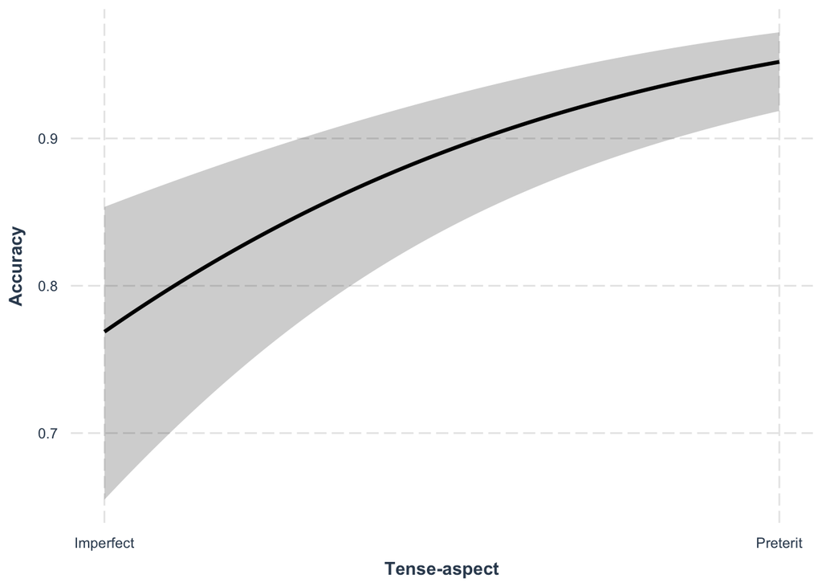

```r
#for tense
effect_plot(model21, pred = tense,
            x.label = 'Tense-aspect',
            y.label = 'Accuracy',
            pred.labels = c('Imperfect', 'Preterit'),
            interval = TRUE)
```

Categorical Tense

```
## Confidence intervals for merMod models is an experimental feature. The
## intervals reflect only the variance of the fixed effects, not the random
## effects.
```

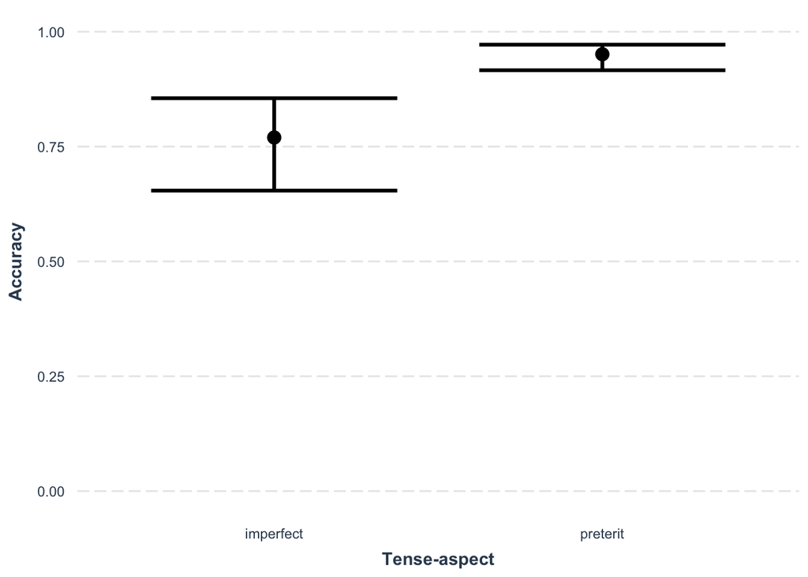

```r
#for tense
effect_plot(model21_092923, pred = Corrected_num,
            x.label = 'Tense-aspect',
            y.label = 'Accuracy',
            pred.labels = c('Imperfect', 'Preterit'),
            interval = TRUE)+
  ylim(0, 1.0)
```

Frequency

```
## Confidence intervals for merMod models is an experimental feature. The
## intervals reflect only the variance of the fixed effects, not the random
## effects.
```

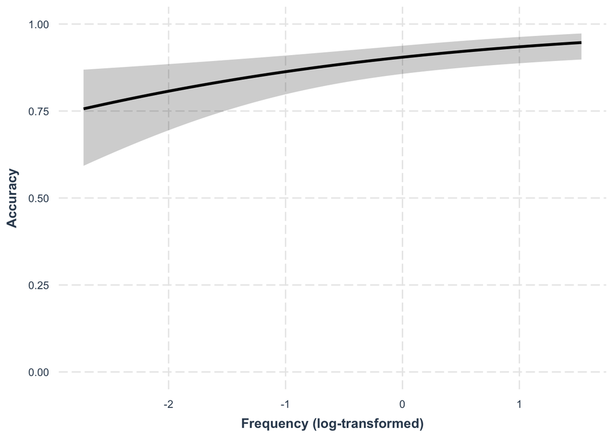

```r
#for frequency
effect_plot(model21, pred = frequency,
            x.label = 'Frequency (log-transformed)',
            y.label = 'Accuracy',
            interval = TRUE)+
  ylim(0, 1.0)
```